# Draft Model to Project a College Player’s Highest WAR Season

Sanjay Pothula

January 4, 2019

### Introduction of Data

With this model, I have made significant adjustments from a previous Random Forest Model. The goal of creating this model was to be able to predict and interpret the future performance of a college prospect, given his statistics in college.

There are many draft models on the internet, but many of them use machine learning techniques without really interpreting the importance of variables within the model and the dependent variable, itself. I have chosen to use a college player’s highest WAR performance within their first 5 years of being in the NBA as the dependent variable. The reason for it is that this should describe a player’s value to a team within the scope of being under team control. In baseball, teams tend to get the most value out of a player within their 6 years of cheap team control. The first 5 years of a NBA contract follows the same concept.

I basically adjusted Basketball-Reference’s BPM and VORP measurement to create a WAR metric, with the replacement level being players signed on 10-day contracts. For this model, I also chose to use a player’s maximum WAR value within their first 5 years of team control as a method to identify star-level talent and to remove the typical poor performance within a player’s first year in the league.

### Summary Statistics

My sample included college players drafted between 2000 and 2014. This would obviously exclude high school and international players. In an ideal world, I would have used advanced metrics instead of purely Per Minute statistics, but many of these advanced statistics didn’t find their way onto Basketball-Reference until the 2009-10 season. For each variable, shown below, the data was scaled by each year’s draft class.

- College Year - Number of years in college
- SOS - Strength of Schedule (College-Reference) - (Figure 1, 2)
- PTS/MP - Points Per Minute - (Figure 3, 4)
- AST/MP - Assists Per Minute - (Figure 5, 6)
- BLK/MP - Blocks Per Minute - (Figure 7, 8)
- STL/MP - Steals Per Minute - (Figure 9, 10)
- TOV/MP - Turnovers Per Minute - (Figure 11, 12)
- TRB/MP - Total Rebounds Per Minute - (Figure 13, 14)
- TS% - True Shooting Percentage - (Figure 15, 16)
- FG3a Per FGA - Three-Point Rate - (Figure 17, 18)
- FTA Per FGA - Free Throw Rate - (Figure 19, 20)
- USG Proxy - Estimated Usage% - (Figure 21, 22)
- TS%/FG3a Per FGA - Interaction between True Shooting% and Three-Point Rate - (Figure 23, 24)
- AST/TRB - Interaction between Assists and Total Rebounds - (Figure 25, 26)

**Update:**

- Age - Age during the player’s final year of college
- Prospect Rank - Use of Chad Ford’s ESPN rankings from 2001 to 2009 and Draft Express’s rankings from 2010 to 2018

### Motivation for Use of Linear Model

I had experimented with many types of models including a Neural Network, Random Forest, and Ridge Regression model. Although each model demonstrated similar performance, the interpretation of the variables was rather complicated. I chose to stick with a linear regression that produced similar results because of the ease of interpretation and overall understanding of the impact of various variables on a player’s future WAR.

In the final model, I chose to exclude usage and PTS/MP because the coefficients proved to be insignificant and displayed negative coefficients, which would seem counterintuitive to a player’s future value in the NBA. In regression analysis, a lot of people feel the need to remove variables if they prove to be not significant, but the removal of variables can impact how other variables interact with the dependent variable. So, there must be an intuitive reason to remove a variable based on the direction of the coefficient and its significance, together. This is the reason why AST/MP, BLK/MP, and TRB/MP were not removed from the model.

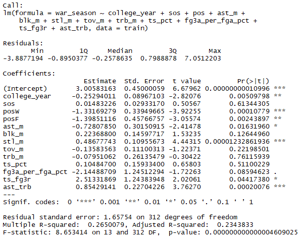

**Update:**

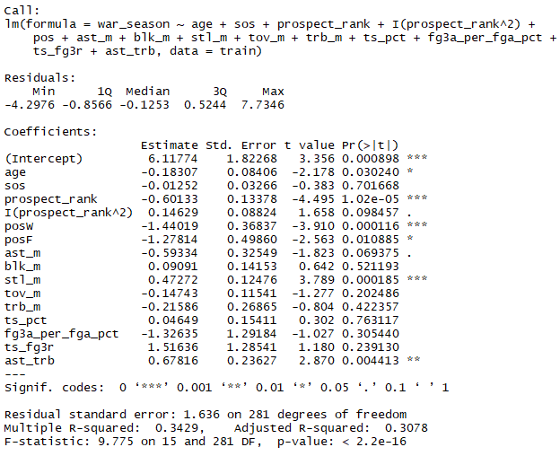

I was able to incorporate age into the model as a substitute for year in college (college_year). The coefficient shows a smaller negative coefficient than college_year, demonstrating a more conservative estimate for every incremental increase in age.

In addition, I included ESPN prospect rankings, which improved the model performance. As the coefficient shows, there is non-linear effect with every increase in a prospect rank or decrease in perception of the player’s future value.

**Update:**

In addition, to the Stat-Influenced model, I have used another model, which incorporates the results of the NBA Combine. This is a two-layered model with the combine-infused WAR prediction being the Bayesian Prior. Initially, an xgboost model utilizes combine data (Measurements, Strength/Agility) to predict a player’s Max WAR season within their first 5 seasons in the NBA

Then a Bayesian model is used with the xgboost model prediction as the Bayesian prior and collegiate statistics as the covariates.

[figure not shown]

[figure not shown]

### How does the model match up against the competition?

**Stats-Infused Model**

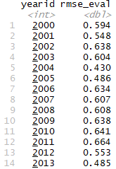

**Combine-Infused Model**

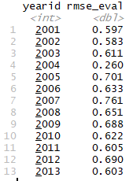

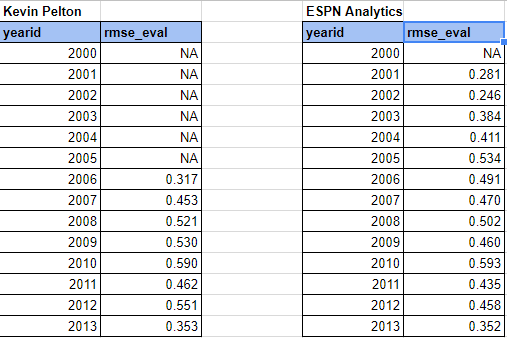

Using the experimental accuracy score metric from To The Mean (http://www.tothemean.com/tools/draft-models/#/), I was able to calculate how the model performs compared to other competitors such as Kevin Pelton and ESPN Analytics. The accuracy score is calculated through the use of the overall/worst root mean squared error between the actual vs expected rankings. As shown above, the model proves to be competitive with other models with the rmse_eval (accuracy) being similar and, in some cases, higher in particular years.

### 2019 Draft Class So Far (January 4th)

Below, I have listed my top 6 players for the 2019 draft class. With no surprise, Zion Williamson is ranked first in the model’s projection. As a forward, he is as dynamic as could be with, contributing in many ways offensively and defensively. From Murray State, Ja Morant is ranked second. In his sophomore season, his 55.3% assist rate and above average rebounding ability is the main reason for his rise as a top prospect in this draft. He would likely be the number one prospect if he had played a more difficult schedule (SOS: -0.85, Zion Williamson’s SOS: 6.75). Interestingly enough, Tre Jones (2.67 WAR) is ranked ahead of RJ Barrett (2.31 WAR). While Tre Jones may have a higher steal rate (3.5%) than Barrett (1.8%), the difference between the two players may have to do with Barrett’s role in Duke’s lineup. As a Wing player, he is treated with more negative value, which could change with a different role in the NBA.

[figure not shown]

### Appendix

**Figure 1: Top 10 SOS**

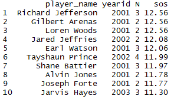

**Figure 2: Bottom 10 SOS**

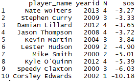

**Figure 3: Top 10 PTS/MP**

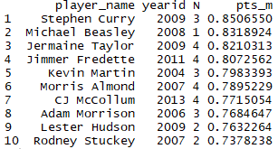

**Figure 4: Bottom 10 PTS/MP**

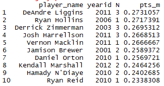

**Figure 5: Top 10 AST/MP**

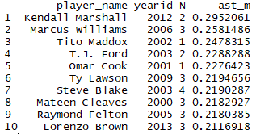

**Figure 6: Bottom 10 AST/MP**

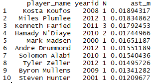

**Figure 7: Top 10 BLK/MP**

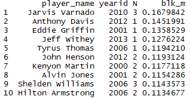

**Figure 8: Bottom 10 BLK/MP**

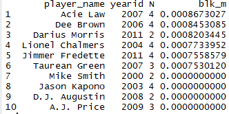

**Figure 9: Top 10 STL/MP**

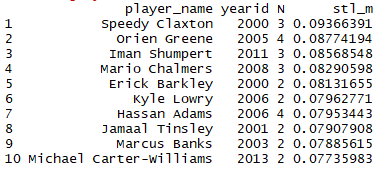

**Figure 10: Bottom 10 STL/MP**

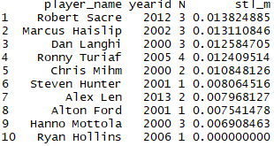

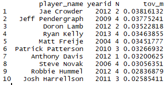

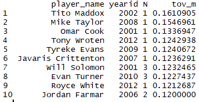

**Figure 13: Top 10 TRB/MP**

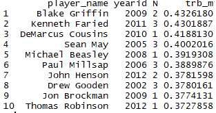

**Figure 14: Bottom 10 TRB/MP**

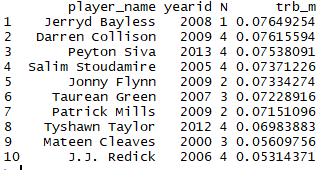

**Figure 15: Top 10 TS%**